# HW 3

Britt Bovbjerg

2/12/2020

## Tips at Restaurants

```r
data(tips, package="reshape2")
```

1. How many parties did the waiter serve? Store the number in `numParty` and print.

```r
numParty <- nrow(tips)
numParty
```

```
## [1] 244
```

The waiter served 244 parties.

2. What are the types of variables in the data frame `tips`? Include the code and also explain verbally.

```r
str(tips)
```

```
## 'data.frame':    244 obs. of  7 variables:
##  $ total_bill: num  17 10.3 21 23.7 24.6 ...
##  $ tip       : num  1.01 1.66 3.5 3.31 3.61 4.71 2 3.12 1.96 3.23 ...
##  $ sex       : Factor w/ 2 levels "Female","Male": 1 2 2 2 1 2 2 2 2 2 ...
##  $ smoker    : Factor w/ 2 levels "No","Yes": 1 1 1 1 1 1 1 1 1 1 ...
##  $ day       : Factor w/ 4 levels "Fri","Sat","Sun",..: 3 3 3 3 3 3 3 3 3 3 ...
##  $ time      : Factor w/ 2 levels "Dinner","Lunch": 1 1 1 1 1 1 1 1 1 1 ...
##  $ size      : int  2 3 3 2 4 4 2 4 2 2 ...
```

The data frame contains 7 variables. Total_bill and tip are numbers(number that can have decimal places), size is an interger (only whole number values) and sex, smoker, day and time are all factors.

3. Create a vector named `day` containing the day of visits in `tips`. The factor levels should be ordered from Thursday to Sunday. Print the variable.

```r
lvl <- levels(tips$day)
lvl2 <- c(lvl[4], lvl[1:3])
day1 <- factor(tips$day, levels = lvl2)
day1
```

```
##   [1] Sun  Sun  Sun  Sun  Sun  Sun  Sun  Sun  Sun  Sun  Sun  Sun  Sun  Sun
##  [15] Sun  Sun  Sun  Sun  Sun  Sat  Sat  Sat  Sat  Sat  Sat  Sat  Sat  Sat
##  [29] Sat  Sat  Sat  Sat  Sat  Sat  Sat  Sat  Sat  Sat  Sat  Sat  Sat  Sun
##  [43] Sun  Sun  Sun  Sun  Sun  Sun  Sun  Sun  Sun  Sun  Sun  Sun  Sun  Sun
##  [57] Sat  Sat  Sat  Sat  Sat  Sat  Sat  Sat  Sat  Sat  Sat  Sat  Sat  Sat
##  [71] Sat  Sat  Sat  Sat  Sat  Sat  Sat  Thur Thur Thur Thur Thur Thur Thur
##  [85] Thur Thur Thur Thur Thur Thur Fri  Fri  Fri  Fri  Fri  Fri  Fri  Fri
##  [99] Fri  Fri  Fri  Fri  Sat  Sat  Sat  Sat  Sat  Sat  Sat  Sat  Sat  Sat
## [113] Sun  Sun  Sun  Sun  Sun  Thur Thur Thur Thur Thur Thur Thur Thur Thur
## [127] Thur Thur Thur Thur Thur Thur Thur Thur Thur Thur Thur Thur Thur Thur
## [141] Thur Thur Thur Thur Thur Thur Thur Thur Thur Thur Sun  Sun  Sun  Sun
## [155] Sun  Sun  Sun  Sun  Sun  Sun  Sun  Sun  Sun  Sun  Sun  Sun  Sun  Sun
## [169] Sat  Sat  Sat  Sat  Sun  Sun  Sun  Sun  Sun  Sun  Sun  Sun  Sun  Sun
## [183] Sun  Sun  Sun  Sun  Sun  Sun  Sun  Sun  Sun  Thur Thur Thur Thur Thur
## [197] Thur Thur Thur Thur Thur Thur Thur Thur Thur Thur Sat  Sat  Sat  Sat
## [211] Sat  Sat  Sat  Sat  Sat  Sat  Sat  Sat  Sat  Sat  Fri  Fri  Fri  Fri
## [225] Fri  Fri  Fri  Sat  Sat  Sat  Sat  Sat  Sat  Sat  Sat  Sat  Sat  Sat
## [239] Sat  Sat  Sat  Sat  Sat  Thur
## Levels: Thur Fri Sat Sun
```

4. Create a data frame named `female5` containing the meal paid by a female payer in a party with size greater than or equal to 5. Print the data frame.

```r
female5 <- tips[tips$size >=5 & tips$sex == "Female",]
female5
```

|  | total_bill | tip | sex | smoker | day | time | size |
| --- | --- | --- | --- | --- | --- | --- | --- |
| 126 | 29.80 | 4.20 | Female | No | Thur | Lunch | 6 |
| 144 | 27.05 | 5.00 | Female | No | Thur | Lunch | 6 |
| 156 | 29.85 | 5.14 | Female | No | Sun | Dinner | 5 |

5. How does the tipping amount (`tip`) depend on the overall bill (`total_bill`)? Use the `ggplot2` package to make a chart. Describe the relationship in words.

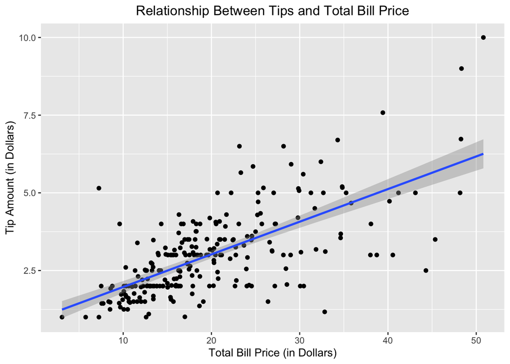

```r
library(ggplot2)
ggplot(tips, aes(x=total_bill, y=tip)) + geom_point() + stat_smooth(method=lm) + labs(title="Relationship Between Tips and Total Bill Price", x = "Total Bill Price (in Dollars)", y = "Tip Amount (in Dollars)") + theme(plot.title = element_text(hjust = 0.5))
```

There’s a moderate, positive trend between the total bill (in dollars) and tips (in dollars).

6. Describe at least two types of anomalies in the previous plot. What do they mean?

There are several outliers in the y direction, especially the $10 tip on the $50 bill. However this is a 20% tip which is unexpected because many people tip at 15-20%

7. Introduce a variable `tiprate` into the data set which stands for the rate of tips. What is the average rate for tips? Explain verbally.

```r
tips$tiprate <- tips$tip / tips$total_bill
mean(tips[,"tiprate"])
```

```
## [1] 0.1608026
```

The average tip rate is 16.1%, meaning that on average people about 16% of their bill as a tip.

8. Make a boxplot of the tip rate by time. The x-axis should be ordered by lunch and then dinner. Use `ggplot2` to make a chart. Verbally explain the chart.

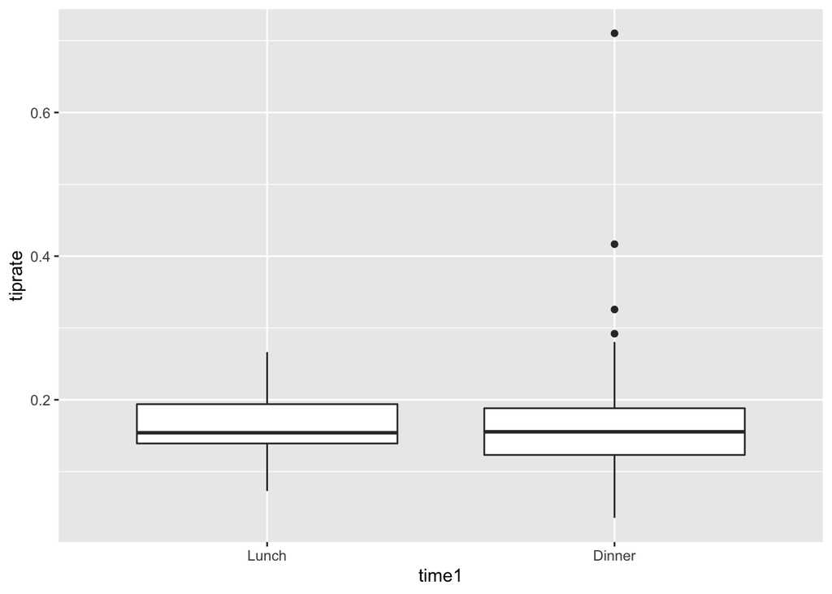

```r
lvl1 <- rev(levels(tips$time))
time1 <- factor(tips$time, levels =lvl1)

ggplot(tips, aes(x=time1, y=tiprate))+ geom_boxplot()
```

9. How does smoking behavior and gender of the person who pays impact the relationship between tip and total bill? Find a visualization that incorporates all four variables. Interpret the result.

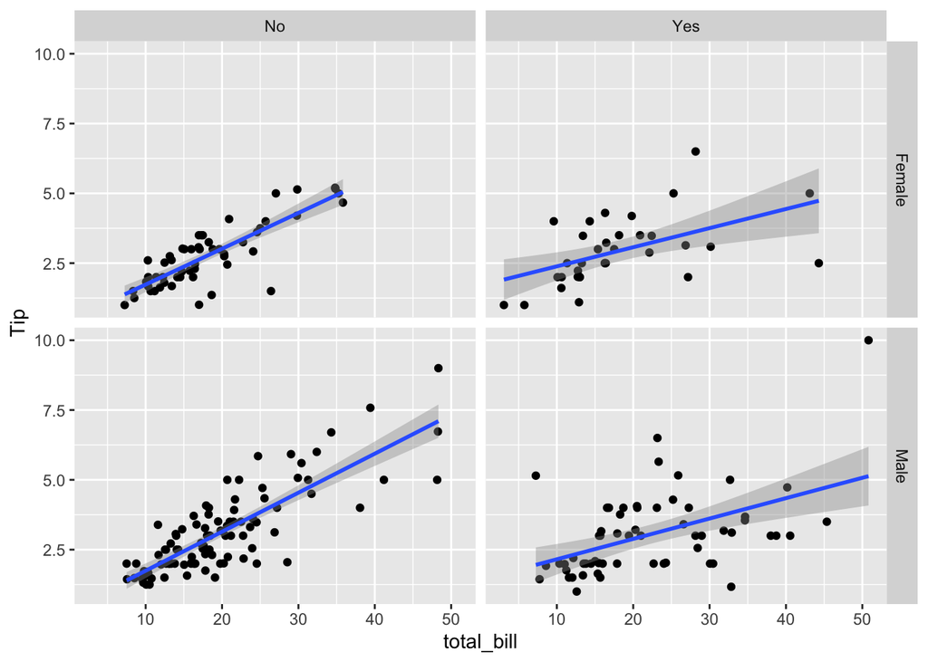

```r
ggplot(tips, aes(x=total_bill, y=tip)) + geom_point() +facet_grid(sex ~ smoker) + ylab("Tip") + stat_smooth(method=lm)
```

Looking at the slopes of the best fit lines, it looks that there is no significant diffference in tipping rate between male and female payers but that smokers have a lower rate of tipping than nonsmokers.

10. Use ggplot2 to find a graphical summary of the relationship between day of the week and gender of the person paying the bill. What can you say about this relationship?

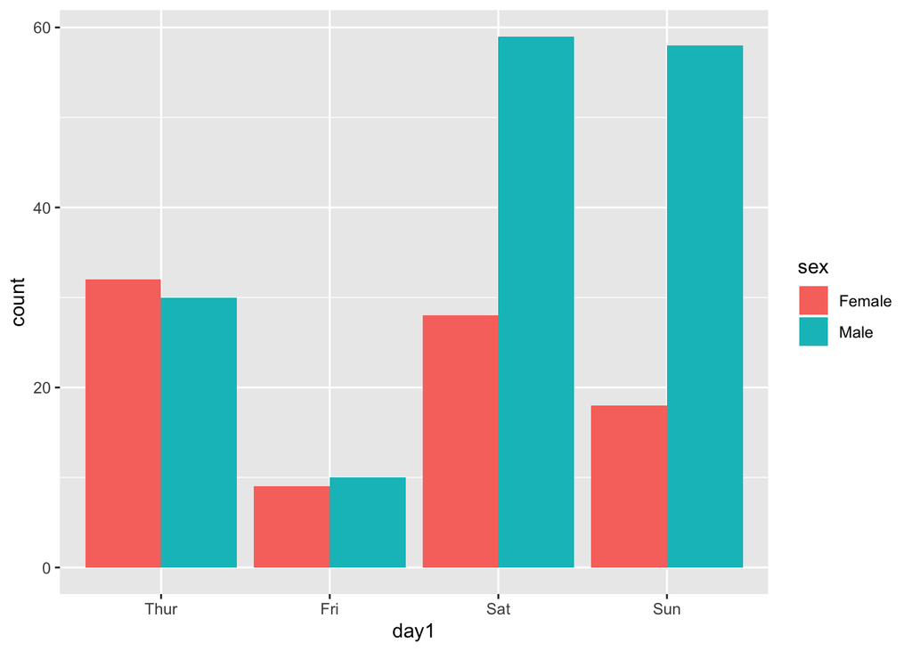

```r
ggplot(tips, aes(day1)) + geom_bar(aes(fill = sex), position = "dodge")
```

Woman are more likely to pay the bill on Thursday, and less likely to pay the bill on friday, saturday and sunday, with sunday being the day women are least likely to pay. However, correlation does not equal causation and there may be other factors at play (like what proportion of the people who came in that day were parties of just women or just men, or men and women going on datas on the weekend so men paid, etc).